# Zeitnahe Lösungen für die Corona-Epidemie

19.04.2022

**Der SNF unterstützt Forschung zum Coronavirus. Mit Erfolg: Bereits liegen relevante Ergebnisse vor.**

Die Corona-Epidemie, mit der wir seit Anfang 2020 konfrontiert sind, hat einmal mehr gezeigt, wie wichtig Forschung ist. Für wirksame Medikamente, Impfstoffe und Präventionsmassnahmen musste das noch unbekannte Virus möglichst rasch entschlüsselt werden. Der SNF leistete einen Beitrag dazu, indem er vielfältige Forschungsprojekte finanzierte. Ein Überblick.

### Erforschung eines unbekannten Virus

Insgesamt finanzierte der SNF 107 Projekte zum Coronavirus mit 45 Millionen Franken. Ein Teil der Projekte ist bereits abgeschlossen, andere laufen noch.

Die Vielfalt dieser Projekte zum Coronavirus veranschaulicht eine Wortwolke, die widerspiegelt, wie häufig bestimmte Schlüsselwörter in den einzelnen Projekten verwendet wurden. Der Fokus der Forschung liegt demnach darauf, das Virus und die damit verbundenen Gesundheitsrisiken zu verstehen.

Wortwolke der Projekte zu Covid-19

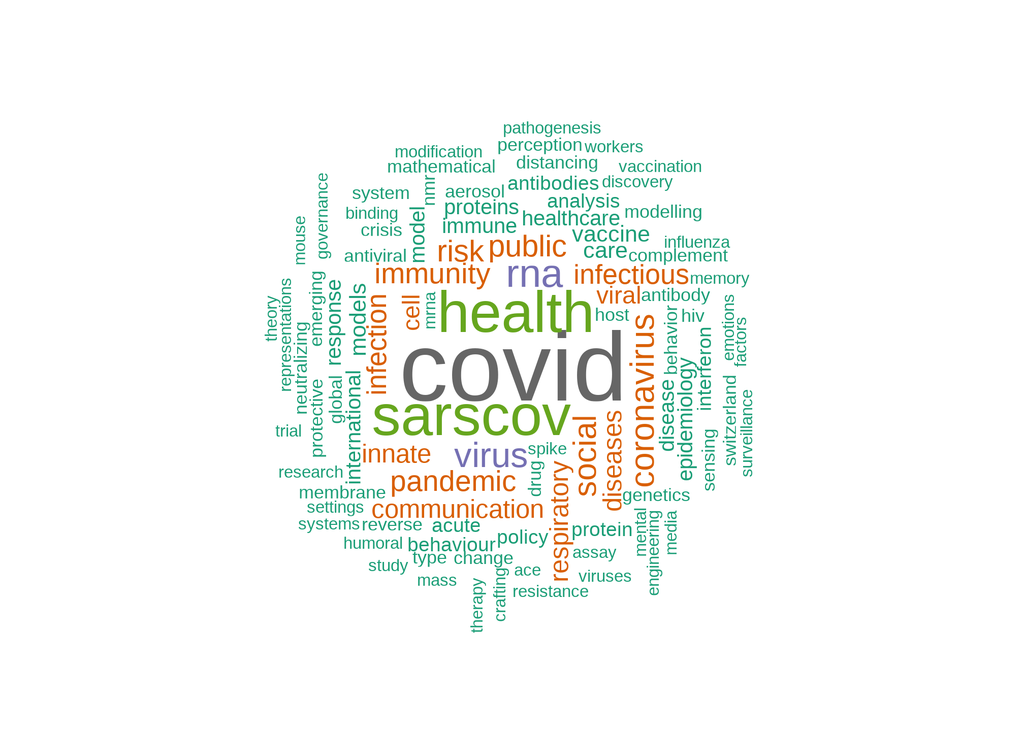

### Verschiedene Formen der Unterstützung

Die Forschung wurde mit verschiedenen Förderinstrumenten unterstützt, vor allem durch die Sonderausschreibung «Coronaviren» (45 Projekte ab Sommer 2020) und das im Auftrag des Bundesrates lancierte [Nationale Forschungsprogramm «Covid-19» (NFP 78)](https://www.nfp78.ch/en/) (28 Projekte). Auch im Rahmen der klassischen Projektförderung reichten Wissenschafterinnen und Wissenschafter Gesuche ein, die in engerem oder weiterem Sinn mit dem Coronavirus zusammenhängen – bereits vor der SARS-CoV-2-Pandemie und seit dem Ausbruch. Gefördert werden in diesem Rahmen 34 Projekte mit insgesamt 184 Beitragsempfangenden.

Anzahl und Anteil der Projekte zu Covid-19 (insgesamt 107) innerhalb der Förderinstrumente

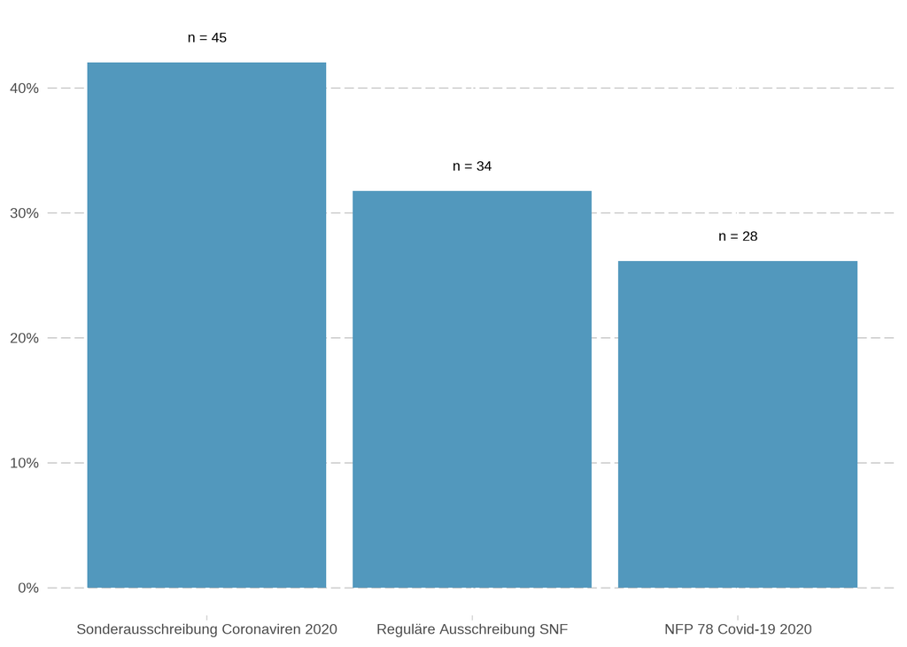

### Relevante Ergebnisse

Die durchschnittliche Laufzeit von Projekten zum Coronavirus beträgt zwei Jahre. Von einigen Projekten liegen bereits Ergebnisse und Publikationen vor, die Fortschritte bei der Bekämpfung der Pandemie brachten: 87 Publikationen im Bereich Lebenswissenschaften und 32 Publikationen in den Geistes- und Sozialwissenschaften. Weitere werden folgen, da 69% der Projekte noch nicht abgeschlossen sind.

Zwei Beispiele:

- Die Gruppe von Volker Thiel, Virologe an der Universität Bern und am Institut für Virologie und Immunologie (IVI), zeigt in einer Publikation, dass der entwickelte Lebendimpfstoff in Form eines Nasensprays vielversprechend ist. Der Impfstoff wird nun mit klinischen Studien weiterentwickelt.
- Ein [Artikel](https://www.manchesteropenhive.com/view/journals/hrv/7/2/article-p41.xml), bei dem der Forscher Marc-Antoine Berthod Mitautor war, befasst sich mit der Bestattungspraxis, die sich in der Pandemie verändert hat.

Auch der SNF hat bereits über Ergebnisse berichtet, insbesondere über:

- Ein [statistisches Modell](https://www.snf.ch/de/BZARkjTMtrt48Gcb/news/einfluss-von-grenz-und-schulschliessungen-auf-die-eindaemmung-des-coronavirus) zur Messung der Auswirkungen von Grenz- und Schulschliessungen
- Die Schaffung eines [nicht-ansteckenden Modells von SARS-CoV-2](https://www.snf.ch/de/IR4xqilNfvUoe4E7/news/modell-von-sars-cov-2-verbessert-forschung-und-entwicklung-von-medikamenten) zur Optimierung der Forschung und Entwicklung für Medikamente
- Eine [Kohortenstudie](https://www.snf.ch/de/6AywkKU0LqBlQ92j/news/long-covid-neue-studienergebnisse) (3000 Personen), bei der sich ein Zusammenhang zwischen der Schwere der Infektion und dem Auftreten von Long-Covid-Symptomen zeigte
- Eine Methode zur schnellen und günstigen Schätzung des [R-Werts](https://www.snf.ch/de/Mhz1a3piOEoSgb2B/news/mit-abwasser-schnell-und-kostenguenstig-zum-r-wert) des Coronavirus anhand von Abwasseranalysen
- Die Entwicklung [Schweizer Impfstoffkandidaten](https://www.nfp78.ch/news/schweizer-impfstoffkandidaten-starten-in-klinische-studienphase/) im Rahmen des NFP 78 ([siehe auch](https://www.snf.ch/de/XZ6J2kZHkf5aMROA/news/innovative-forschung-zu-neuen-impfstoffen))

### Lebenswissenschaften an der Spitze

Eine genauere Analyse der unterstützten Projekte zeigt, dass fast zwei Drittel aus dem Bereich Lebenswissenschaften (LW) stammen, knapp ein Drittel aus geistes- und sozialwissenschaftlichen Disziplinen (GSW) und nur eine geringe Anzahl aus den MINT-Disziplinen (Mathematik, Informatik, Naturwissenschaften, Technik). Diese Verteilung ist eine logische Folge der Probleme, die im Zusammenhang mit der Pandemie zu lösen sind. Bei den vom SNF unterstützten Projekten insgesamt sind hingegen alle Disziplinen gleichmässig vertreten.

Die Verteilung wird sich mit dem 2021 lancierten Nationalen Forschungsprogramm [«Covid-19 in der Gesellschaft»](https://www.nfp80.ch/en/) (NFP 80) ändern. Dieses NFP richtet sich vor allem an die Geistes- und Sozialwissenschaften. Die Projekte werden im Laufe des Sommers 2022 ausgewählt.

Anzahl und Anteil der Projekte zu Covid-19 (insgesamt 107) nach Forschungsbereich

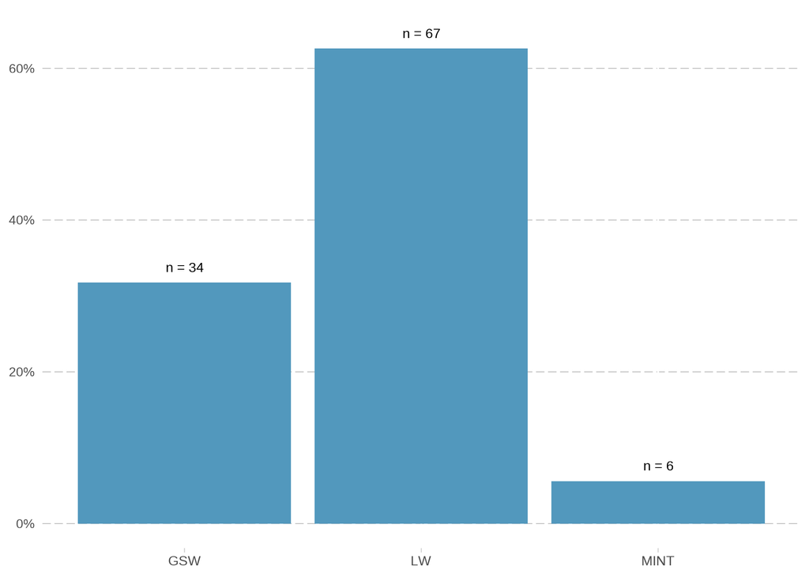

Gesamtbetrag der bewilligten Mittel (in Franken) für die 107, Projekte zu Covid-19 nach Forschungsbereich

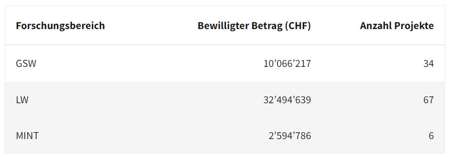

| Forschungsbereich | Bewilligter Betrag (CHF) | Anzahl Projekte |
| --- | --- | --- |
| GSW | 10’066’217 | 34 |
| LW | 32’494’639 | 67 |
| MINT | 2’594’786 | 6 |

Die folgende Abbildung zeigt die Anzahl und den Anteil der Projekte der einzelnen Disziplinen bei der Forschung zum Coronavirus. Die Präventivmedizin steht wenig überraschend zuoberst auf der Rangliste. Danach folgt die biologische Grundlagenforschung, wo es in den meisten Projekten darum geht, das Virus besser zu verstehen. Einige Projekte aus den Geistes- und Sozialwissenschaften befassen sich hingegen mit den Reaktionen der Gesellschaft und mit den Folgen der Pandemie.

Anzahl und Anteil von Projekten zu Covid-19 (insgesamt 107) in den einzelnen Disziplinen

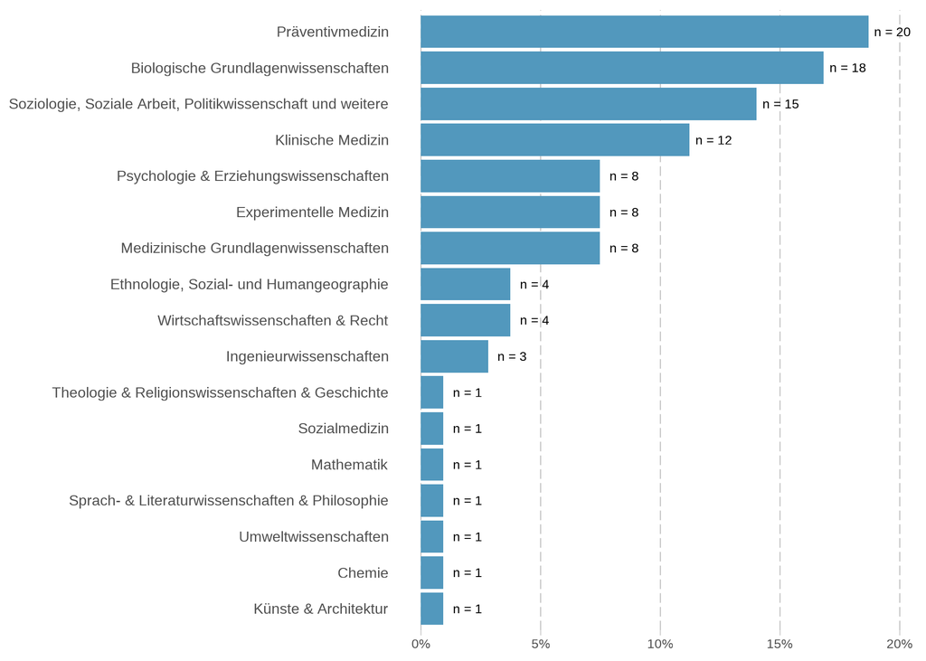

### Grundlagenforschung ist teuer

Grundlagenforschung ist teuer: Am meisten Mittel – nämlich 10,7 Millionen Franken – flossen in die biologische Grundlagenforschung.

Bewilligter Gesamtbetrag (in Franken) für Forschungsprojekte in den sieben häufigsten Disziplinen

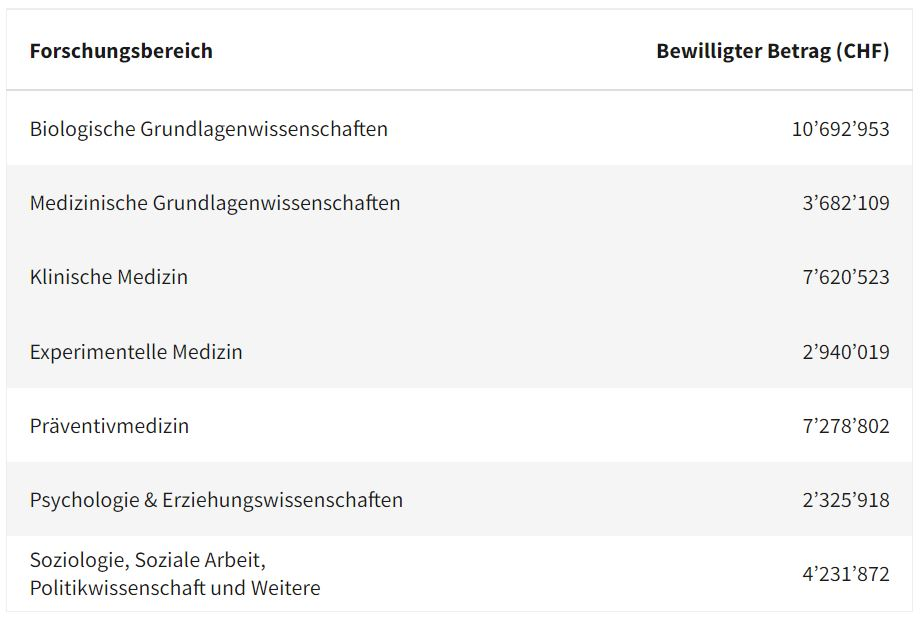

| Forschungsbereich | Bewilligter Betrag (CHF) |
| --- | --- |
| Biologische Grundlagenwissenschaften | 10’692’953 |
| Medizinische Grundlagenwissenschaften | 3’682’109 |
| Klinische Medizin | 7’620’523 |
| Experimentelle Medizin | 2’940’019 |
| Präventivmedizin | 7’278’802 |
| Psychologie & Erziehungswissenschaften | 2’325’918 |
| Soziologie, Soziale Arbeit, Politikwissenschaft und weitere | 4’231’872 |

### Covid-19-Projektregister

Alle Forschungsprojekte zum Coronavirus werden in [einem Register](https://data.snf.ch/covid-19) erfasst.

Dieses Projektregister bietet einen Überblick über die Covid-19-Forschung in der Schweiz, die vom SNF, von Innosuisse und vom Europäischen Forschungsrahmenprogramm Horizon 2020 finanziert wird.

Daten, Text und Code dieser Datengeschichte sind auf [Github](https://github.com/snsf-data/datastory_covid_19_funding) verfügbar und auf [Zenodo](https://doi.org/10.46446/datastory.covid-19-funding) archiviert. DOI: 10.46446/datastory.covid-19-funding